# Does Defense Win Championships in the NBA?

### Nick DeLuca, Spring 2018

## The Question

Across most team sports, there are varying ideas about what makes a good team. This is also the case in basketball, a personal favorite of mine. There are teams that pride themselves in their fast pace offense that puts up a lot of points per game, and others put an emphasis on shutting their opponents down on the defensive end of the court.

There is a saying in football: defense wins championships. Does stellar defense correlate to wins in the NBA as well, or is offense the more important factor? In this analysis, that question will be answered.

### 1.0 Setup

The following libraries will be required:

```r
library(lubridate)
library(dplyr)
library(data.table)
library(ggplot2)
library(broom)
library(purrr)
library(tidyverse)
library(randomForest)
library(tidyr)
```

### 2.0 Data Curation and Management

The dataset we will be using is a CSV file of statistics for each game of the NBA regular season from 2014-2018. This dataset can be found on Kaggle here: https://www.kaggle.com/ionaskel/nba-games-stats-from-2014-to-2018

Let’s first load the dataset and take a look at a few observations to get a feel for the data.

```r
games <- read.csv("./nba.games.stats.csv")

games %>%
  head(3)
```

```
##   X Team Game       Date Home Opponent WINorLOSS TeamPoints OpponentPoints
## 1 1  ATL    1 2014-10-29 Away      TOR         L        102            109
## 2 2  ATL    2 2014-11-01 Home      IND         W        102             92
## 3 3  ATL    3 2014-11-05 Away      SAS         L         92             94
##   FieldGoals FieldGoalsAttempted FieldGoals. X3PointShots
## 1         40                  80       0.500           13
## 2         35                  69       0.507            7
## 3         38                  92       0.413            8
##   X3PointShotsAttempted X3PointShots. FreeThrows FreeThrowsAttempted
## 1                    22         0.591          9                  17
## 2                    20         0.350         25                  33
## 3                    25         0.320          8                  11
##   FreeThrows. OffRebounds TotalRebounds Assists Steals Blocks Turnovers
## 1       0.529          10            42      26      6      8        17
## 2       0.758           3            37      26     10      6        12
```

[output cut: 21 more lines]

We can see that each observation in the dataframe contains the team, date, home/away status, opposing team, whether the team won or lost, and numerous statistical categories for both the home and the away team. There is a ton of useful information here to form predictors from, but we are going to need to make some changes to get where we want to. One such change is converting the “Date” attribute to a datetime object to make it easier to extract information from later on. It might also be useful to create a field to represent what year the season started in, because the NBA’s regular season begins in October and ends in April.

```r
games <- games %>%
  mutate(Date = as.Date(Date, '%Y-%m-%d')) %>%
  mutate(Season.Start = ifelse(month(Date)<5, year(Date)-1, year(Date)))
```

### 2.1 Creating new fields

Right now, the statistics we have for each team are for the game corresponding to that observation. This could be interesting, but its not really useful for a prediction model, because if you already know the stats for a game you know the result. What might be useful is season averages for the stats.

We will create new attributes for each team’s averages for 9 offensive and 9 defensive stats, as they might come in handy later. To do this we will first group by Team and Season_Start, then calculate totals. As for the column names, “per game” will be abbreviated as “PG”. For the teams’ defensive statistics, column names will be given the suffix “A” for “Allowed”.

```r
games <- games %>%
  group_by(Team,Season.Start) %>%
  mutate(Games = max(Game)) %>%
  mutate(W_bin = ifelse(WINorLOSS=="W",1L,0L)) %>%
  mutate(Wins = sum(W_bin)) %>%
  mutate(Losses = as.integer(max(Game)-Wins-0L)) %>%
  mutate(PointsPG = sum(TeamPoints)/Games) %>%
  mutate(FGAttemptsPG = sum(FieldGoalsAttempted)/Games) %>%
  mutate(SeasonFGPercent = sum(FieldGoals)/sum(FieldGoalsAttempted)) %>%
  mutate(x3PtAttemptsPG = sum(X3PointShotsAttempted)/Games) %>%
  mutate(Season3PtPercent = sum(X3PointShots)/sum(X3PointShotsAttempted)) %>%
  mutate(FTAttemptsPG = sum(FreeThrowsAttempted)/Games) %>%
  mutate(AssistsPG = sum(Assists)/Games) %>%
  mutate(OffReboundsPG = sum(OffRebounds)/Games) %>%
  mutate(TurnoversPG = sum(Turnovers)/Games) %>%
  mutate(Opp.PointsPG = sum(OpponentPoints)/Games) %>%
  mutate(Opp.FGPercent = sum(Opp.FieldGoals)/sum(Opp.FieldGoalsAttempted)) %>%
  mutate(Opp.3ptPercent = sum(Opp.3PointShots)/sum(Opp.3PointShotsAttempted)) %>%
  mutate(StealsPG = sum(Steals)/Games) %>%
  mutate(BlocksPG = sum(Blocks)/Games) %>%
  mutate(FoulsPG = sum(TotalFouls)/Games) %>%
  mutate(DefensiveRebounds = sum(TotalRebounds-OffRebounds)/Games) %>%
  mutate(Opp.FTAttempts = sum(Opp.FreeThrowsAttempted)/Games) %>%
  mutate(Opp.TurnoversPG = sum(Opp.Turnovers)/Games) %>%
  ungroup() %>%
  as.data.frame()
```

### 2.2 Organizing Data

Now that we have our averages, our dataframe is a bit crowded. Let’s clean it up a bit and make some data tables to organize the data we want to hold onto. We’ll make one that holds each team’s defensive stats for each season, one that holds offensive stats for each season, and one that stores minimal data about all of the games.

#### 2.2.1 Team Offense by Season

```r
SeasonStatsDT <- games %>%
  select(Team,Season.Start,Games,Wins,Losses,PointsPG,FGAttemptsPG,SeasonFGPercent,x3PtAttemptsPG,Season3PtPercent,
         FTAttemptsPG,AssistsPG,OffReboundsPG,TurnoversPG) %>%
  data.table(key = "Team,Season.Start")

SeasonOffenseDT <- SeasonStatsDT[, head(.SD, 1), by = key(SeasonStatsDT)]
SeasonOffenseDT
```

```
##      Team Season.Start Games Wins Losses  PointsPG FGAttemptsPG
##   1:  ATL         2014    82   60     22 102.54878     81.69512
##   2:  ATL         2015    82   48     34 102.84146     84.42683
##   3:  ATL         2016    82   43     39 103.15854     84.36585
##   4:  ATL         2017    82   24     58 103.35366     85.53659
##   5:  BOS         2014    82   40     42 101.36585     87.93902
##  ---
## 116:  UTA         2017    82   48     34 104.14634     82.89024
## 117:  WAS         2014    82   46     36  98.53659     82.80488
## 118:  WAS         2015    82   41     41 104.07317     85.76829
## 119:  WAS         2016    82   49     33 109.18293     87.03659
## 120:  WAS         2017    82   43     39 106.60976     85.58537
##      SeasonFGPercent x3PtAttemptsPG Season3PtPercent FTAttemptsPG
##   1:       0.4658904       26.24390        0.3801115     21.15854
##   2:       0.4576051       28.36585        0.3503869     19.97561
```

[output cut: 21 more lines]

#### 2.2.2 Team Defense by Season

```r
SeasonStatsDT <- games %>%
  select(Team,Season.Start,Games,Wins,Losses,Opp.PointsPG,Opp.FGPercent,Opp.3ptPercent,StealsPG,BlocksPG,FoulsPG,
         DefensiveRebounds,Opp.FTAttempts,Opp.TurnoversPG) %>%
  data.table(key = "Team,Season.Start")

SeasonDefenseDT <- SeasonStatsDT[, head(.SD,1), by = key(SeasonStatsDT)]
SeasonDefenseDT
```

```
##      Team Season.Start Games Wins Losses Opp.PointsPG Opp.FGPercent
##   1:  ATL         2014    82   60     22     97.12195     0.4388848
##   2:  ATL         2015    82   48     34     99.23171     0.4315670
##   3:  ATL         2016    82   43     39    104.01220     0.4441649
##   4:  ATL         2017    82   24     58    108.80488     0.4693303
##   5:  BOS         2014    82   40     42    101.20732     0.4500936
##  ---
## 116:  UTA         2017    82   48     34     99.84146     0.4492945
## 117:  WAS         2014    82   46     36     97.81707     0.4332262
## 118:  WAS         2015    82   41     41    104.57317     0.4615609
## 119:  WAS         2016    82   49     33    107.37805     0.4661794
## 120:  WAS         2017    82   43     39    106.02439     0.4618387
##      Opp.3ptPercent StealsPG BlocksPG  FoulsPG DefensiveRebounds
##   1:      0.3409091 9.073171 4.634146 17.76829          31.84146
##   2:      0.3381474 9.109756 5.926829 19.14634          33.80488
```

[output cut: 21 more lines]

#### 2.2.3 Game Info

```r
GamesDT <- games %>%
  select(Team,Game,Season.Start,Opponent,WINorLOSS) %>%
  data.table()
GamesDT
```

```
##       Team Game Season.Start Opponent WINorLOSS
##    1:  ATL    1         2014      TOR         L
##    2:  ATL    2         2014      IND         W
##    3:  ATL    3         2014      SAS         L
##    4:  ATL    4         2014      CHO         L
##    5:  ATL    5         2014      NYK         W
##   ---
## 9836:  WAS   78         2017      HOU         L
## 9837:  WAS   79         2017      CLE         L
## 9838:  WAS   80         2017      ATL         L
## 9839:  WAS   81         2017      BOS         W
## 9840:  WAS   82         2017      ORL         L
```

### 3.0 Exploratory Data Analysis

So, we have the data organized now. Whats next?

We should make some plots in order to vizualize our data and get a sense of any trends that might be easily spotted. Because we want to compare the impact of offense and defense, we can start to look at that idea with these plots.

#### 3.1 Offense Analysis

Our goal is to get a simplified view of some trends that might be present in our data set. To accomplish this, let’s explore the relationship between points scored and winning. The number of points a team scores should be a fairly good indicator of how strong the team’s offense is, so it is a good attribute to use to look for patterns.

Here is a plot comparing each team’s total wins for a season and their points scored per game. We would expect this relationship to be fairly linear, which is why we’ll use the option “method = lm”.

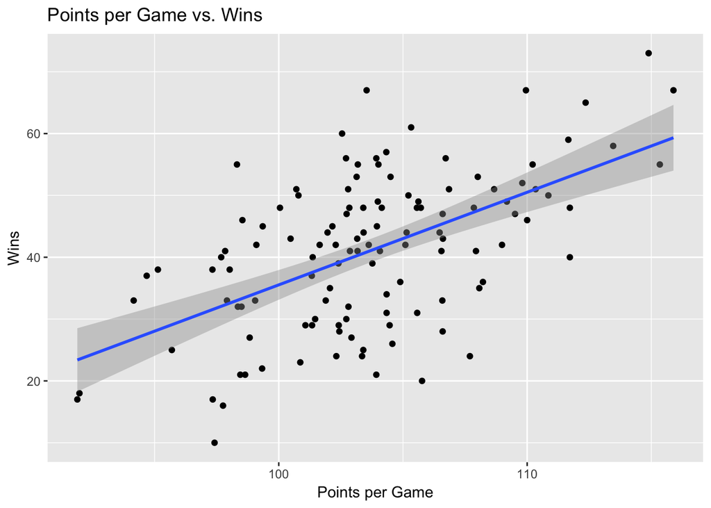

```r
SeasonOffenseDT %>%
  as.data.frame() %>%
  ggplot(mapping = aes(x=PointsPG, y=Wins)) + geom_point() + geom_smooth(method = lm) +
  labs(title="Points per Game vs. Wins",
       x="Points per Game",
       y="Wins")
```

As you might expect, there appears to be a considerable relationship between points per game and number of wins. Now lets take a look at individual games. We can plot the points scored in a game against a binary win/loss result, where 1 represents a win and 0 represents a loss.

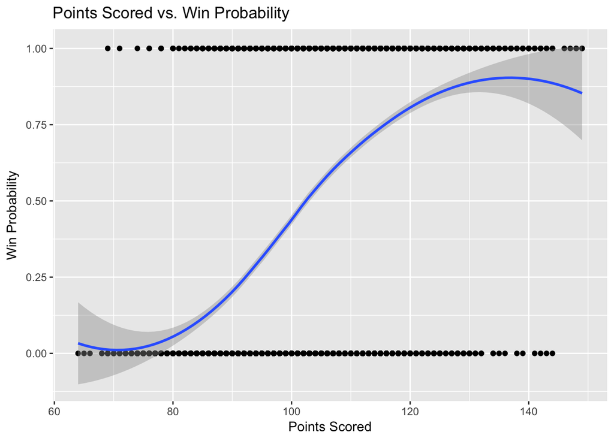

```r
games %>%
  ggplot(mapping = aes(x=TeamPoints,y=W_bin)) + geom_point() + geom_smooth(method = loess) +
  labs(title="Points Scored vs. Win Probability",
       x="Points Scored",
       y="Win Probability")
```

Again, this looks about how one might expect. Interestingly, the probability of winning starts to trend back downwards once a team reaches about 137 points. Why would this be the case?

One possible reason is that the team scored that much by playing at a very fast pace and taking a lot of shots. Then, the other team would have just as many opportunities to score themselves. Another possible reason would be that the game went into overtime so there was more time to score points. This would mean that the game is very close and the other team has a good chance to win still. In both cases, this would be indicated by a high number of field goal attempts. Let’s make one more plot of the chance of winning for number of field goal attempts.

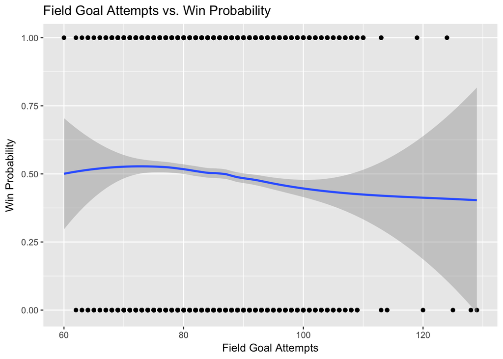

```r
games %>%
  ggplot(mapping = aes(x=FieldGoalsAttempted,y=W_bin)) + geom_point() + geom_smooth(method = loess) +
  labs(title="Field Goal Attempts vs. Win Probability",
       x="Field Goal Attempts",
       y="Win Probability")
```

This is an interesting result. Although there doesn’t seem to be a significant correlation between shots attempted and winning, win percentage does appear to decrease slightly as shot attempts increase, and there is much more variabilty when shot attempts are high. This variability likely has something to do with the fact that there are fewer data points where shot attempts are very high, but there are 6 losses where shot attempts exceed 110 and only 3 such wins.

This begs the question, do teams that attempt many shots in a game usually maintain an efficient shooting percentage while doing so? We can plot field goal attempts against field goal percentage to find out.

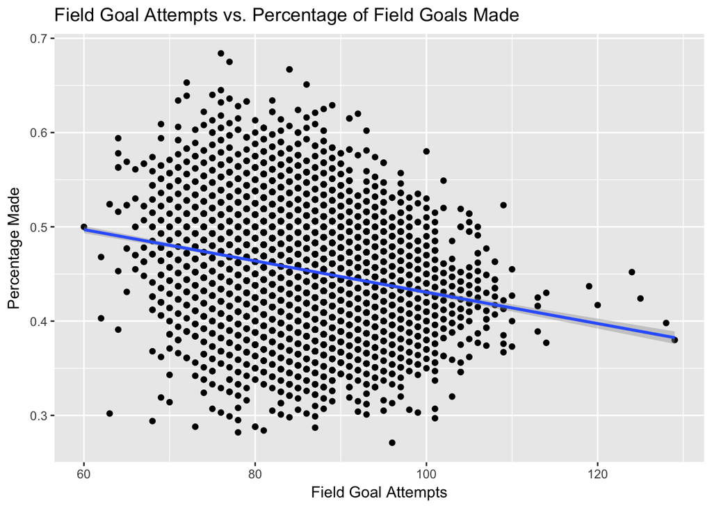

```r
games %>%
  ggplot(mapping = aes(x=FieldGoalsAttempted,y=FieldGoals.)) + geom_point() + geom_smooth(method = lm) +
  labs(title="Field Goal Attempts vs. Percentage of Field Goals Made",
       x="Field Goal Attempts",
       y="Percentage Made")
```

While there is not a ton of correlation here, we can see that teams that attempt an abnormally high amount of field goals in a game tend to make a relatively low percentage of their shots.

#### 3.2 Defense Analysis

Now let’s take a look at some of the defensive stats and how they relate to wins. Similarly to offense, points allowed per game should give us a decent idea of how defense relates to wins.

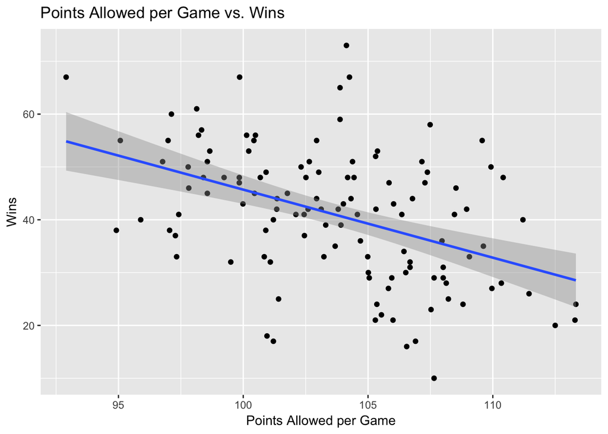

```r
SeasonDefenseDT %>%
  as.data.frame() %>%
  ggplot(mapping = aes(x=Opp.PointsPG,y=Wins)) + geom_point() + geom_smooth(method = lm) +
  labs(title="Points Allowed per Game vs. Wins",
       x="Points Allowed per Game",
       y="Wins")
```

It appears that there is a similarly strong relationship between points allowed per game and winning as we saw with points scored per game and winning. If we look at points allowed in individual games and the result, the plot should be exactly the inverse of the points scored in individual games plot. Let’s plot it just to be sure.

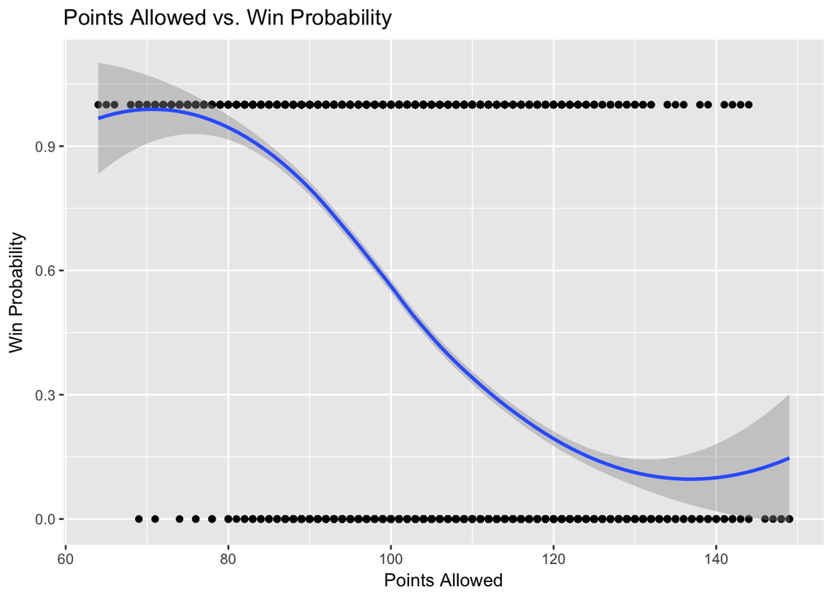

```r
games %>%
  ggplot(mapping = aes(x=OpponentPoints,y=W_bin)) + geom_point() + geom_smooth(method = loess) +
  labs(title="Points Allowed vs. Win Probability",
       x="Points Allowed",
       y="Win Probability")
```

As expected, win probability plummets as points allowed increases before beginning to trend back upwards as points allowed reaches the very high end.

### 4.0 Machine Learning

We are going to use machine learning models to see if there is a difference in the predictive capabilities of a model that uses offensive statistics and one that uses defensive statistics.

#### 4.2 Data Preparation

We want to predict the results of a game using a team’s season averages compared to their opponents. To do this, we will prepare matrices for the teams’ offensive/defensive stats and their opponents’ offensive/defensive stats for all the games. We will then subtract the opponents’ offense matrix from the other offense matrix, and do the same for defense. The result will be two matrices containing the difference between in offensive stats between the two teams in a game, and the same for defense. We will also add a column for the result of the game for the machine learning model to use in training and testing.

```r
offDF <- data.frame()
defDF <- data.frame()

for(row in 1:nrow(GamesDT))
{
  team <- GamesDT[row, get('Team')]
  opp <- GamesDT[row, get('Opponent')]
  season <- GamesDT[row, get('Season.Start')]
  outcome <- GamesDT[row, get('WINorLOSS')]

  teamOff <- subset(SeasonOffenseDT, get('Team')==team & get('Season.Start')==season) %>%
    select(-Team,-Season.Start,-Games,-Wins,-Losses)

  oppOff <- subset(SeasonOffenseDT, get('Team')==opp & get('Season.Start')==season) %>%
    select(-Team,-Season.Start,-Games,-Wins,-Losses)

  diffOff <- teamOff-oppOff
  diffOff <- diffOff %>%
    cbind(outcome)
  offDF <- offDF %>%
    rbind(diffOff)

  teamDef <- subset(SeasonDefenseDT, get('Team')==team & get('Season.Start')==season) %>%
    select(-Team,-Season.Start,-Games,-Wins,-Losses)

  oppDef <- subset(SeasonDefenseDT, get('Team')==opp & get('Season.Start')==season) %>%
    select(-Team,-Season.Start,-Games,-Wins,-Losses)

  diffDef <- teamDef-oppDef
  diffDef <- diffDef %>%
    cbind(outcome)
  defDF <- defDF %>%
    rbind(diffDef)
}
offDF %>%
  head()
```

```
##      PointsPG FGAttemptsPG SeasonFGPercent x3PtAttemptsPG Season3PtPercent
## 1: -1.4390244   -1.5853659     0.010772552       1.121951       0.02768434
## 2:  5.2195122   -1.5243902     0.026558661       5.024390       0.02838739
## 3: -0.6341463   -1.8902439    -0.002157424       3.719512       0.01357119
## 4:  8.3902439   -2.8414634     0.045665388       7.146341       0.06210386
## 5: 10.6585366   -0.3292683     0.037403961       6.560976       0.03314746
## 6: 10.6585366   -0.3292683     0.037403961       6.560976       0.03314746
##    FTAttemptsPG AssistsPG OffReboundsPG TurnoversPG outcome
## 1:   -3.4024390  5.000000     -2.024390  1.25609756       L
## 2:   -1.0000000  4.317073     -1.719512  0.12195122       W
## 3:   -0.2317073  1.353659     -1.109756 -0.01219512       L
## 4:   -1.6097561  5.573171     -1.280488  2.28048780       L
## 5:    1.9512195  4.451220     -1.853659 -0.31707317       W
## 6:    1.9512195  4.451220     -1.853659 -0.31707317       W
```

```r
defDF %>%
  head()
```

```
##    Opp.PointsPG Opp.FGPercent Opp.3ptPercent StealsPG    BlocksPG
## 1:  -3.79268293  -0.020228197   -0.005370997 1.573171  0.28048780
## 2:   0.07317073   0.004185520   -0.004099666 2.914634  0.06097561
## 3:   0.13414634  -0.004782291   -0.019090909 1.060976 -0.78048780
## 4:  -0.20731707  -0.001155986   -0.016469764 2.987805 -0.82926829
## 5:  -4.08536585  -0.020914944   -0.039364882 2.060976 -0.02439024
## 6:  -4.08536585  -0.020914944   -0.039364882 2.060976 -0.02439024
##       FoulsPG DefensiveRebounds Opp.FTAttempts Opp.TurnoversPG outcome
## 1: -3.1097561          1.036585     -3.3170732        1.646341       L
## 2: -3.4756098         -2.573171     -3.6585366        3.256098       W
## 3: -1.3048780         -1.963415     -1.2560976        1.878049       L
## 4: -0.4512195         -2.219512     -0.2682927        3.365854       L
## 5: -3.7926829          2.048780     -4.6463415        2.000000       W
## 6: -3.7926829          2.048780     -4.6463415        2.000000       W
```

#### 4.3 Modeling

```r
offDF <- offDF %>%
  mutate(outcome=factor(outcome, levels=c("L", "W")))

defDF <- defDF %>%
  mutate(outcome=factor(outcome, levels=c("L", "W")))

set.seed(1264)
test_random_forest_off <- offDF %>%
  group_by(outcome) %>%
  sample_frac(.3) %>%
  ungroup()

train_random_forest_off <- offDF %>%
  anti_join(test_random_forest_off)
rf <- randomForest(outcome~., mtry=1, data=train_random_forest_off)
rf
```

```
##
## Call:
##  randomForest(formula = outcome ~ ., data = train_random_forest_off,      mtry = 1)
##                Type of random forest: classification
##                      Number of trees: 500
## No. of variables tried at each split: 1
##
##         OOB estimate of  error rate: 39.51%
## Confusion matrix:
##      L    W class.error
## L 1485  869   0.3691589
## W  986 1355   0.4211875
```

```r
test_predictions <- predict(rf, newdata=test_random_forest_off)
table(pred=test_predictions, observed=test_random_forest_off$outcome)
```

```
##     observed
## pred   L   W
##    L 636 902
##    W 840 574
```

The offense-based model did not perform well. It only predicted 41% of the test cases correctly. There may have been too many attributes that were not impactful. Let’s try to cut it down to the relationships we saw were strong earlier.

```r
test_random_forest_off <- offDF %>%
  group_by(outcome) %>%
  sample_frac(.3) %>%
  ungroup()

train_random_forest_off <- offDF %>%
  anti_join(test_random_forest_off)
rf <- randomForest(outcome~PointsPG*SeasonFGPercent, data=train_random_forest_off)
rf
```

```
##
## Call:
##  randomForest(formula = outcome ~ PointsPG * SeasonFGPercent,      data = train_random_forest_off)
##                Type of random forest: classification
##                      Number of trees: 500
## No. of variables tried at each split: 1
##
##         OOB estimate of  error rate: 37.92%
## Confusion matrix:
##      L    W class.error
## L 1526  837   0.3542107
## W  936 1377   0.4046693
```

```r
test_predictions <- predict(rf, newdata=test_random_forest_off)
table(pred=test_predictions, observed=test_random_forest_off$outcome)
```

```
##     observed
## pred   L   W
##    L 532 977
##    W 944 499
```

Removing weaker relationships did not prove to make the predictions more accurate either. In fact, the error rate was higher. Let’s see about defense.

```r
test_random_forest_def <- defDF %>%
  group_by(outcome) %>%
  sample_frac(.3) %>%
  ungroup()

train_random_forest_def <- defDF %>%
  anti_join(test_random_forest_def)
rf <- randomForest(outcome~., mtry=1, data=train_random_forest_def)
rf
```

```
##
## Call:
##  randomForest(formula = outcome ~ ., data = train_random_forest_def,      mtry = 1)
##                Type of random forest: classification
##                      Number of trees: 500
## No. of variables tried at each split: 1
##
##         OOB estimate of  error rate: 38.45%
## Confusion matrix:
##      L    W class.error
## L 1443  871   0.3764045
## W  911 1409   0.3926724
```

```r
test_predictions <- predict(rf, newdata=test_random_forest_def)
table(pred=test_predictions, observed=test_random_forest_def$outcome)
```

```
##     observed
## pred   L   W
##    L 600 955
##    W 876 521
```

The defensive model did not perform well either. It only predicted 38% of the test cases correct. Again, let’s try using only a couple predictors.

```r
test_random_forest_def <- defDF %>%
  group_by(outcome) %>%
  sample_frac(.3) %>%
  ungroup()

train_random_forest_def <- defDF %>%
  anti_join(test_random_forest_def)
rf <- randomForest(outcome~Opp.PointsPG*Opp.FGPercent, data=train_random_forest_def)
rf
```

```
##
## Call:
##  randomForest(formula = outcome ~ Opp.PointsPG * Opp.FGPercent,      data = train_random_forest_def)
##                Type of random forest: classification
##                      Number of trees: 500
## No. of variables tried at each split: 1
##
##         OOB estimate of  error rate: 38.66%
## Confusion matrix:
##      L    W class.error
## L 1496  881   0.3706353
## W  945 1401   0.4028133
```

```r
test_predictions <- predict(rf, newdata=test_random_forest_def)
table(pred=test_predictions, observed=test_random_forest_def$outcome)
```

```
##     observed
## pred    L    W
##    L  566 1012
##    W  910  464
```

Once again, the error rate was still very high. This model also performed worse than the one with more predictors.

### Conclusion

Overall, the models both performed very similarly. Neither one was very accurate, with the offense predicting 41% of the test cases correctly and the defense predicting 38% of the test cases correctly. Unfortunately, it seems like there is just too much game-to-game variance in team performance to predict the outcome of a game using statistical averages.